# Assignment 6: A mountain holiday for Alan

## Overview

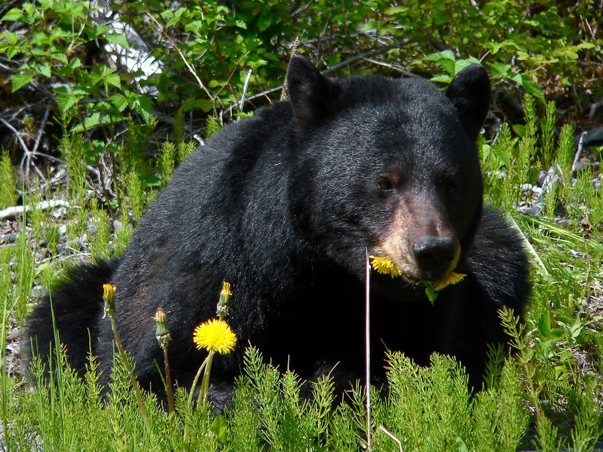

*A frighteningly “goofy” American Black Bear munching dandelions*

Being a student takes a lot of energy and patience – especially when your teacher is someone as annoying as me. At the end of every semester Alan McQuinn likes to take a short mountain holiday to regain his strength. This semester, after dealing with me for more than four months, Alan really needs it. Right after the semester ends, Alan is going to get the rest and relaxation he deserves in Pisgah National Forest – a stunningly beautiful spot in the Blue Ridge Mountains near Asheville, North Carolina. Let’s send him on an awesome, rejuvenating, Brian-free, vacation!

In this exercise, you’ll help Alan find the perfect spots to stargaze, stay warm, search for waterfalls, get some quiet time, and, most importantly, avoid goofy bears!

When I create an R Markdown file to communicate a coding process, I usually work in a .R script file and copy-and-paste the code into the R Markdown document at the end.

**Important**

To receive full credit for a given question, please ensure that the result you provide **only** answers the given question. For example, in the table below, if you were asked to determine the value in column `b` where column `a` is equal to “hello” you would provide the following code:

```r
tibble(
  a = c('hello', 'world'),
  b = 1:2) %>%
  filter(a == 'hello') %>%
  pull(b)
```

```
## [1] 1
```

## Grading

The points allotted for each question are provided in highlighted red bold text (e.g., [1.0]) within the question itself. When applicable, total points for a question may represent the sum of individually graded components, which are provided in red text (e.g., [1.0]).

**Points may be deducted from each question’s total:**

- Use only functions other than those listed in “Functions that you may use in this assignment” [50%]
- Do not include any assignments other than those specified in the question [50%]
- Unless specified otherwise, each question must be answered in a single piped statement [50%]
- Include a comment at the start of each code block [25%]
- Include a comment for each line of code that modifies a dataset [10% per violation]
- Ensure that all code is properly indented [10% per violation]
- Ensure that your code follows modern coding conventions (see *Best practices in modern R coding*) [10% per violation]

*Note: The maximum deduction is the total points value for a given question*

You must ensure that your R Markdown document **runs out-of-the-box** – in other words, the document will knit without error. Some tips for doing so:

- Do not maintain your project folder in a location that is backed up by an online directory (e.g., Dropbox, iCloud)
- Ensure that all file paths are equivalent to those in this document (e.g., in `source()` or `read_csv()`)
- Do not use `setwd()` in your code (**Never** use `setwd()`!)
- If one of your code chunks contains an error, include `eval = FALSE` in the options for that chunk
- Prior to submission, clear all objects from your global environment prior to knitting your R Markdown document

In this assignment, you may use **only** the following R functions (*Note: If you are unclear on what a given function does, use `?` to view the help file!*):

- base:: ::
- base::<-
- base::=
- base::<
- base::>
- base::<=
- base::>=
- base::!
- base::+
- base::-
- base::*
- base::/
- base::$
- base::!
- base::~
- base::(
- base::)
- base::{
- base::}
- base::as.matrix
- base::c
- base::is.na
- base::library
- base::names
- base::rm
- base::source
- dplyr::if_else
- dplyr::filter
- dplyr::mutate
- dplyr::pull
- dplyr::slice
- dplyr::transmute
- grDevices::gray.colors
- grDevices::terrain.colors
- magrittr::%>%
- purrr::keep
- purrr::map
- sf::st_as_sf
- sf::st_coordinates
- sf::st_crs
- sf::st_set_crs
- spatstat::as.owin
- spatstat::ppp
- stats::density
- stars::st_as_stars
- stringr::str_detect
- terra::as.points
- terra::classify
- terra::crop
- terra::distance
- terra::ext
- terra::extract
- terra::mask
- terra::rast
- terra::resample
- terra::shade
- terra::terrain
- terra::vect
- tibble::tibble
- tibble::tribble
- tmap … any tmap function you would like!

*Note: The packages dplyr, ggplot2, magrittr, readr, rlang, and tibble are all part of the tidyverse and are loaded with `library(tidyverse)`.*

## Getting started

Open R Studio. Please ensure that the Global Options for R Markdown are set to “Show output preview in Viewer Pane”. This will allow you to view the knitted document (i.e., the html version of this file) right next to your code.

As always, please ensure that you are starting with a clean session. Please do the following before continuing:

- If there are any script files open in your source pane. Close them. If any of the file titles are blue, save them prior to closing.
- In the *Environment* tab of your **workspace pane**, ensure that your **global environment** is empty. If it is not, click the *broom* to remove all objects.
- In the *History* tab of your **workspace pane**, ensure that your history is empty. If it is not, click the *broom* to remove your history.

1. [0.5] Save and knit this document:

- Replace my name in the YAML header with yours [0.1]
- Add the current date in the YAML header [0.1]
- Save the *.rmd* file in the **output** folder of your project as (*but replace my name with yours*): `assignment_6_Evans_Brian.rmd` [0.3]

## The setup

**All** of my scripts start with a setup section where I load libraries, set session options, conduct initial data loading, and early processing steps.

2. [0.5] Setup your session:

- [0.15] Load the `spatstat`, `sf`, `tmap`, and `tidyverse` libraries.

```r
# Paste your code in here!
```

- [0.15] Set the tmap mode to “view” for the entire document:

```r
# Paste your code in here!
```

- [0.2] Load the data using the source script `source_script_holiday_Alan.R`:

```r
# Paste your code in here!
```

3. [0.5] Using iteration, subset each raster file in `rasters_start` to the extent below [0.3] and assign the results to your global environment as a list object with the name “rasters_reduced” [0.1]:

| Coordinate | Value |
| --- | --- |
| Minimum longitude | 1172400 |
| Maximum longitude | 1211000 |
| Minimum latitude | 1433000 |
| Maximum latitude | 1472000 |

```r
# Paste your code in here!
```

- [0.1] Remove the original raster files from the global environment:

```r
# Paste your code in here!
```

4. [1.0] Processing climate variables:

- [0.25] Using iteration, set the resolution of the `rasters_reduced$precip` and `rasters_reduced$tmin` rasters to the resolution of rasters_reduced$canopy;
- [0.25] Convert the modified climate rasters to a raster stack;
- [0.25] Assign the raster stack to the global environment with the name “climate”;

```r
# Paste your code in here!
```

- [0.25] Briefly describe why the climate raster stack should not be used analytically:

```r
# Please supply your answer as a comment here
```

## Helping out ol’ Alan

With our processing complete, we’re now ready to get to the fun part – extracting meaningful data!

*Aside: I know that at least a few of you (Xavier? Rui? Anyone?) are saying to yourself, “but Brian, the processing **is** the fun part”. If so, I get it, but we’ve at least got to pretend otherwise …*

5. [1.0] Alan sure is excited about his trip! Make him a nice map of the topography of Western North Carolina. Use the `rasters_reduced$dem` to:

- [0.25] Calculate the slope of each pixel in radians and assign to your global environment with the name “slope”:

```r
# Paste your code in here!
```

- [0.25] Calculate the aspect of each pixel in radians and assign to your global environment with the name “aspect”:

```r
# Paste your code in here!
```

- [0.25] Generate a hillshade raster and assign to your global environment with the name “hillshade”:

```r
# Paste your code in here!
```

- [0.25] Make a map of the topography with a hillshade to show vertical relief:

```r
# Paste your code in here!
```

6. [1.0] Nobody wants Alan to be chilly. Nobody. We’d better help him figure out where he’ll need to wear his monogrammed Comfy® fleece poncho during his trip:

- [0.75] Using average December temperatures of 2.5 °C as a cutoff, classify Alan’s campsites (`camp_points`) as “Comfy” (temperatures less than 2.5 °C) or “Flannel” (temperatures greater than or equal to 2.5 °C);
- [0.25] Generate a tmap of Alan’s potential `campsites` where the points are colored blue for “Comfy” sites and red for “Flannel” sites.

```r
# Paste your code in here!
```

7. [1.0] On long car rides, Alan likes to entertain his friends by singing “Don’t Go Chasing Waterfalls sha-na-na-na” over-and-over again (punctuated only by shouting “second verse, same as the first!”). *Waterfalls* by TLC might be Alan’s favorite song, but these are not words that he lives by — he loves chasing waterfalls. Transylvania County, which is one of four counties that share the Pisgah National Forest, is known as the “Land of the Waterfalls” (it has 250 large waterfalls and many more small ones). Let’s help him find some:

- [0.2] Calculate the slope of `rasters_reduced$dem` in degrees;
- [0.2] Mask the slope to raster cells that overlay `wnc_streams`;
- [0.2] Convert the raster cells to an sf point point file;
- [0.2] Using slopes that are greater than or equal to 20 degrees as your criteria for a potential waterfall, subset the resultant object to points that fit this criteria;
- [0.2] Generate a nice (but busy!) map of waterfall points for Alan.

```r
# Paste your code in here!
```

8. [1.5] Sometimes ol’ Alan likes to sleep out under the stars to search for UFOs and contemplate the universe. Unfortunately, the air in the mountains can be pretty polluted due to a coal-fired power plant in the valley and atmospheric inversions (phenomena that trap air at low altitudes). Let’s figure out which campsite will provide Alan with the best chance to spot a UFO using the following criteria:

- [0.75] The campsite is 5,000 feet or more above sea level;
- [0.75] The campsite provides a clear view of the night sky (canopy cover <= 10%).

*Note:*

- *You may use up to two assignments in answering this question … but **0.25 points extra credit** if you don’t!*
- *Please return the answer as a single value that represents the name or names of the campsite(s) (i.e., not a data frame).*

```r
# Paste your code in here!
```

9. [1.0] Alan’s never been scared of anything – except for black bear (*Ursus americanus*). “There’s just something goofy about them … I don’t trust goofy” Alan grunted while swirling his scotch in a way that’s *classic Alan*. Help your fellow student steer clear of black bear by generating a density map of black bear in the area.

*Hint: Use the `bears` and `pisgah_region` shapefiles in answering this question.*

```r
# Paste your code in here!
```

10. [2.0]. Alan’s spent weeks listening intently to Brian prattling on in this class. “How could anyone make so many verbal typos?” he asks himself with a long draw from his trademark Gandolf pipe. With the course coming to a close, he’s looking forward to some real peace and quiet. Help Alan get some respite from the din by generating a map that displays the distance from the nearest major road (as a continuous surface).

*Hint: Depending on your choice of target raster, this may take a **long time** to run. As such, I strongly suggest using `rasters_reduced$precip` or `rasters_reduced$tmin` as your target raster!*

```r
# Paste your code in here!
```

**Extra credit** [0.25]: Using data from this assignment, make a super impressive static map of the variable or variables of your choosing!

```r
# Paste your code in here!
```